# Customising Plots

ssdtools Team

2024-10-21

## Plotting the cumulative distributions

The `ssdtools` package plots the cumulative distribution functions using `ssd_plot_cdf()`.

For example, consider the CCME boron data from the [`ssddata`](https://github.com/open-AIMS/ssddata) package. We can fit, and then plot the cdfs as follows.

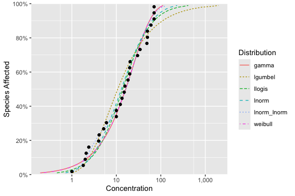

```r
library(ssdtools)
library(ggplot2)

fits <- ssd_fit_dists(ssddata::ccme_boron)
ssd_plot_cdf(fits)
```

This graphic is a [ggplot](https://ggplot2.tidyverse.org) object and so can be customized in the usual way.

For example, we can add the model-averaged cdf by setting `average = NA`, change the string used to separate thousands using `big.mark`, customize the color scale with `scale_color_manual()` and change the theme.

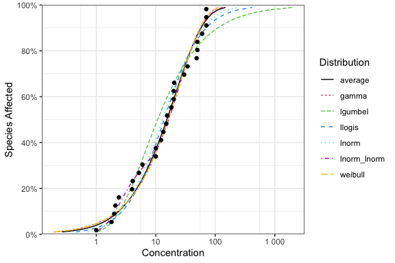

```r
ssd_plot_cdf(fits, average = NA, big.mark = " ") +
  scale_color_manual(name = "Distribution", breaks = c("average", names(fits)), values = 1:7) +
  theme_bw()
```

## ggplot Geoms

The `ssdtools` package provides four ggplot geoms to allow you construct your own plots.

### `geom_ssdpoint()`

The first is `geom_ssdpoint()` which plots species sensitivity data

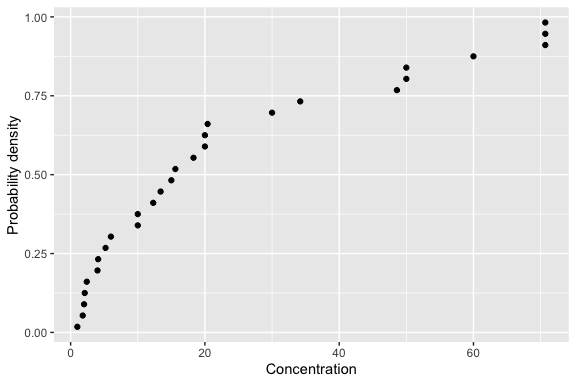

```r
ggplot(ssddata::ccme_boron) +
  geom_ssdpoint(aes(x = Conc)) +
  ylab("Probability density") +
  xlab("Concentration")
```

### `geom_ssdsegments()`

The second is `geom_ssdsegments()` which plots the ranges of censored species sensitivity data

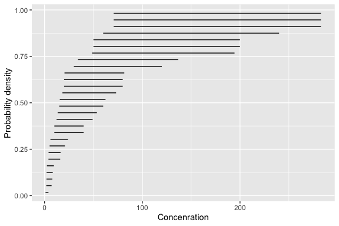

```r
ggplot(ssddata::ccme_boron) +
  geom_ssdsegment(aes(x = Conc, xend = Conc * 4)) +
  ylab("Probability density") +
  xlab("Concenration")
```

### `geom_xribbon()`

The third is `geom_xribbon()` which plots species sensitivity confidence intervals

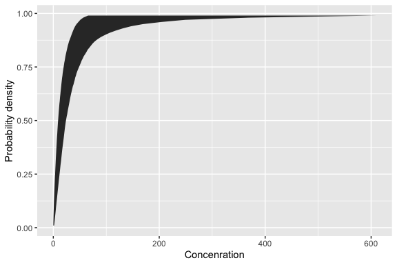

```r
ggplot(boron_pred) +
  geom_xribbon(aes(xmin = lcl, xmax = ucl, y = proportion)) +
  ylab("Probability density") +
  xlab("Concenration")
```

### `geom_hcintersect()`

And the fourth is `geom_hcintersect()` which plots hazard concentrations

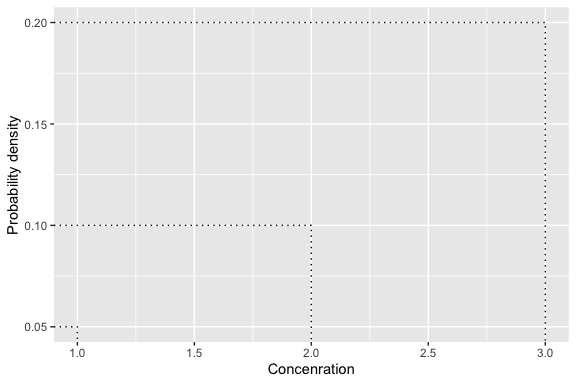

```r
ggplot() +
  geom_hcintersect(xintercept = c(1, 2, 3), yintercept = c(0.05, 0.1, 0.2)) +
  ylab("Probability density") +
  xlab("Concenration")
```

### Putting it together

Geoms can be combined as follows

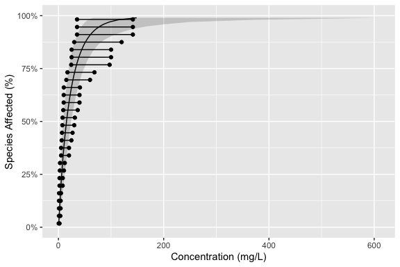

```r
gp <- ggplot(boron_pred, aes(x = est)) +
  geom_xribbon(aes(xmin = lcl, xmax = ucl, y = proportion), alpha = 0.2) +
  geom_line(aes(y = proportion)) +
  geom_ssdsegment(data = ssddata::ccme_boron, aes(x = Conc / 2, xend = Conc * 2)) +
  geom_ssdpoint(data = ssddata::ccme_boron, aes(x = Conc / 2)) +
  geom_ssdpoint(data = ssddata::ccme_boron, aes(x = Conc * 2)) +
  scale_y_continuous("Species Affected (%)", labels = scales::percent) +
  xlab("Concentration (mg/L)") +
  expand_limits(y = c(0, 1))

gp
```

To log the x-axis and include mathematical notation and add the HC5 value use the following code.

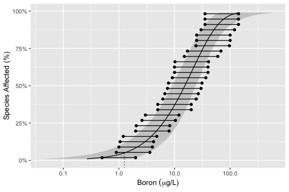

```r
gp +
  scale_x_log10(
    latex2exp::TeX("Boron $(\\mu g$/L)$")
  ) +
  geom_hcintersect(xintercept = ssd_hc(fits)$est, yintercept = 0.05)
```

## Saving plots

The most recent plot can be saved as a file using `ggsave()`, which also allows the user to set the resolution.

```r
ggsave("file_name.png", dpi = 300)
```

## Licensing

Copyright 2015-2023 Province of British Columbia  
Copyright 2021 Environment and Climate Change Canada  
Copyright 2023-2024 Australian Government Department of Climate Change, Energy, the Environment and Water

The documentation is released under the [CC BY 4.0 License](https://creativecommons.org/licenses/by/4.0/)

The code is released under the [Apache License 2.0](https://www.apache.org/licenses/LICENSE-2.0)